# Data Translation Challenge

The COVID-19 pandemic has had widespread and far-reaching effects on the global economy, with the retail sector experiencing particularly significant disruptions. While our company has been able to monitor its own performance during this period, we wish to understand the broader economic impacts, both within retail and across other industries.

To support our investigation into the economic effects of the COVID-19 pandemic, our team analyzed data from the **Current Population Survey (CPS)** provided by **IPUMS**, with a focus on employment trends from the pre-pandemic period through April 2022. By examining shifts in employment at both the individual and industry levels, our goal is to generate meaningful insights into the evolving labor market landscape and assess the performance of the retail sector in comparison to other segments of the economy.

Our analysis is structured around three central research questions:

1. *How has COVID-19 affected the health of the retail industry, as measured by employment?*
2. *How has retail fared relative to other industries?*
3. *What has changed about who is working and earning income during the pandemic?*

```r
# Load Working Data
load("Q1-3 Data Translation Environment.RData")

# Load Libraries
library(ipumsr)
library(tidyverse)
library(janitor)
library(readr)
library(lubridate)
library(zoo)
library(fixest)
library(vtable)
library(gt)
library(broom)
library(rio)
```

### Why We Run These Analyses?

Our primary goal is to measure how employment and unemployment in the retail sector changed due to COVID-19. To do this, we need to:

1. Track employment and unemployment counts over time within the retail industry.

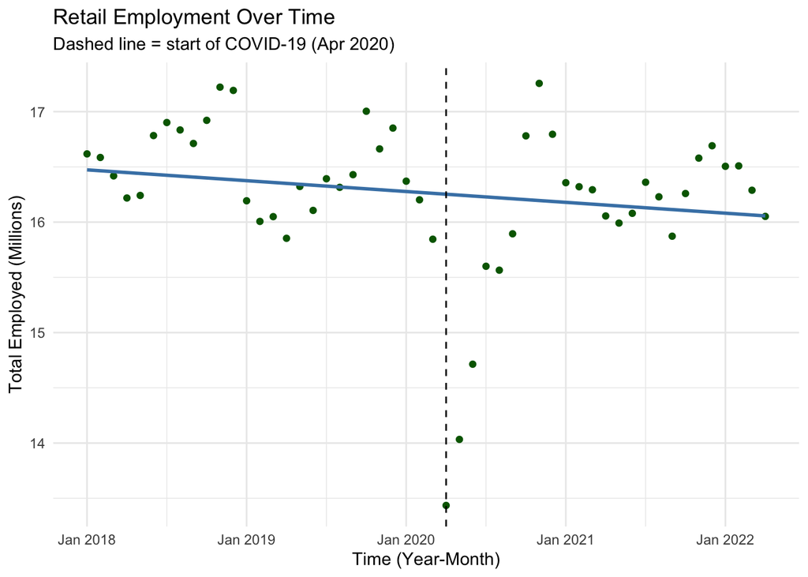

```r
# Plot: Retail Employment Over Time

ggplot(retail_employment, aes(x = year_month, y = total_employed_mil)) +
  geom_point(color = "darkgreen") +
  geom_smooth(method = "lm", se = FALSE, color = "steelblue", linewidth = 1) +
  geom_vline(xintercept = as.yearmon("2020-04", "%Y-%m"), linetype = "dashed", color = "black") +
  labs(
    title = "Retail Employment Over Time",
    subtitle = "Dashed line = start of COVID-19 (Apr 2020)",
    x = "Time (Year-Month)", y = "Total Employed (Millions)"
  ) +
  theme_minimal()
```

The above graph depicts the monthly total employment count in retail sector from the pre-pandemic period through April 2022. The dashed vertical line marks April 2020, the approximate onset of widespread COVID-19 disruptions in the U.S. economy. The **retail employment plot** illustrates a decline in the number of employed retail workers beginning in April 2020, which could be a reflection of job losses due to business closures and reduced consumer demand. After this steep drop, the employment level shows signs of gradual recovery but remains below pre-pandemic levels as of April 2022.

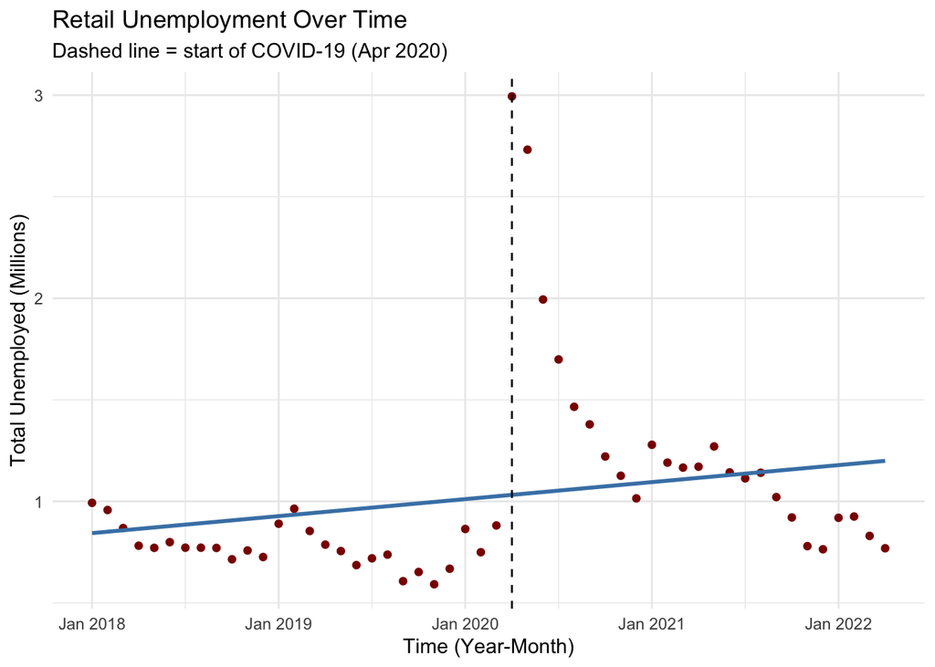

```r
# Plot: Retail Unemployment Over Time

ggplot(retail_unemployment, aes(x = year_month, y = total_unemployed_mil)) +
  geom_point(color = "darkred") +
  geom_smooth(method = "lm", se = FALSE, color = "steelblue", linewidth = 1) +
  geom_vline(xintercept = as.yearmon("2020-04", "%Y-%m"), linetype = "dashed", color = "black") +
  labs(
    title = "Retail Unemployment Over Time",
    subtitle = "Dashed line = start of COVID-19 (Apr 2020)",
    x = "Time (Year-Month)", y = "Total Unemployed (Millions)"
  ) +
  theme_minimal()
```

The **retail unemployment plot** above complements the employment plot by showing a corresponding surge in unemployment among retail workers starting in April 2020. This increase highlights the significant rise in joblessness within retail during the pandemic’s early months, before unemployment begins to gradually trend downward again.

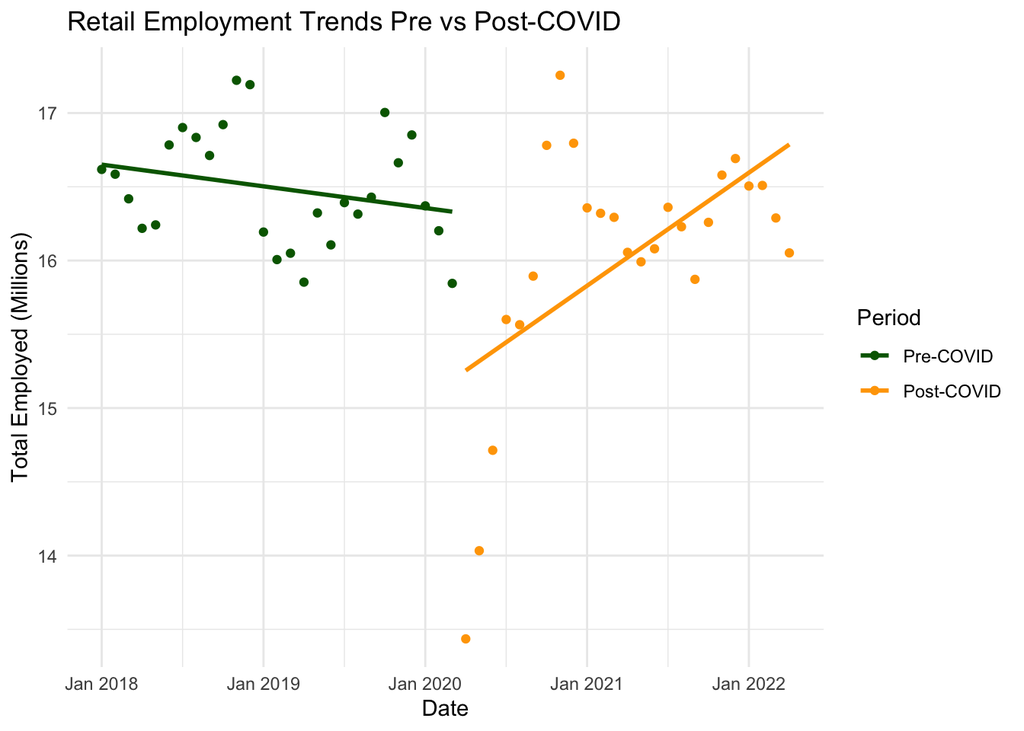

```r
# Retail Employment Pre vs. Post-COVID Plot ---
ggplot(retail_employment, aes(x = year_month, y = total_employed_mil, color = factor(post_covid))) +
  geom_point() +
  geom_smooth(method = "lm", se = FALSE) +
  scale_color_manual(values = c("darkgreen", "orange"), labels = c("Pre-COVID", "Post-COVID")) +
  labs(
    title = "Retail Employment Trends Pre vs Post-COVID",
    x = "Date", y = "Total Employed (Millions)", color = "Period"
  ) +
  theme_minimal()
```

This plot compares retail employment levels before and after the onset of the COVID-19 pandemic. The data points are color-coded to distinguish the two periods, with green representing pre-COVID months and orange representing post-COVID months starting from April 2020.

The distinct change in slope between the pre- and post-pandemic periods quantifies how the crisis altered the trajectory of retail employment, reinforcing the magnitude of disruption experienced by the industry. However, it is also notable that the post-COVID trend line slopes upward, indicating a gradual recovery in retail employment following the initial shock. This suggests that while the sector was severely impacted at the start of the pandemic, there have been positive signs of labor market rebound in retail over time.

2. Statistically test whether there is a significant difference in employment before and after the pandemic onset.

```r
# Retail Employment Regression (Aggregate) ---
model_emp <- feols(total_employed_mil ~ post_covid + month_index, data = retail_employment)
model_unemp <- feols(total_unemployed_mil ~ post_covid + month_index, data = retail_unemployment)
etable(model_emp, model_unemp)
```

```
                         model_emp          model_unemp
Dependent Var.: total_employed_mil total_unemployed_mil

Constant         16.19*** (0.2048)    1.196*** (0.1039)
post_covid       -1.027** (0.3524)    1.270*** (0.1788)
month_index       0.0214. (0.0117)  -0.0296*** (0.0060)
_______________ __________________ ____________________
S.E. type                      IID                  IID
Observations                    52                   52
R2                         0.17554              0.53311
Adj. R2                    0.14189              0.51406
---
Signif. codes: 0 '***' 0.001 '**' 0.01 '*' 0.05 '.' 0.1 ' ' 1
```

To assess the impact of COVID-19 on retail employment, we estimated linear regression models with employment and unemployment levels (in millions) as dependent variables. The key explanatory variable, **post_covid**, is a binary indicator equal to 1 for periods from April 2020 onward, capturing the pandemic’s onset. We also included a linear time trend (**month_index**) to control for underlying trends over the study period.

Results from the employment model show a statistically significant negative coefficient on **post_covid** (-1.027, p < 0.01), indicating that retail employment decreased by approximately 1.03 million jobs immediately after the pandemic began, holding the time trend constant. The positive but marginally significant coefficient on **month_index** (0.0214, p ≈ 0.07) suggests a slight upward trend in employment over time, consistent with a gradual recovery.

In contrast, the unemployment model reveals a significant positive coefficient on **post_covid** (1.270, p < 0.001), indicating an increase of roughly 1.27 million unemployed retail workers immediately following the pandemic’s onset. The negative and highly significant time trend coefficient (-0.0296, p < 0.001) reflects a steady decrease in unemployment over time after the initial spike.

The models explain a moderate portion of the variation in employment (Adjusted R² ≈ 0.14) and a more substantial proportion in unemployment (Adjusted R² ≈ 0.51).

These findings confirm that COVID-19 caused a sharp and immediate drop in retail employment alongside a sharp increase in unemployment, followed by signs of gradual recovery over the subsequent months.

3. Control for confounding factors such as seasonality, time trends, and demographic characteristics that might also affect employment independently of COVID-19.

```r
retail_employment_individual <- retail_data %>%
  mutate(
    employed = if_else(empstat %in% c("At work", "Has job, not at work last week"), 1, 0),
    post_covid = if_else(year_month >= as.yearmon("2020-04", "%Y-%m"), 1, 0)
  ) %>%
  select(year_month, month, statefip, age, race, citizen, wtfinl, employed, post_covid)

model_emp_controls <- feols(
  employed ~ post_covid + factor(month) + factor(statefip) + age + factor(race) + factor(citizen),
  weights = ~wtfinl,
  data = retail_employment_individual
)
```

```
The variables 'age1', 'age2', 'age3', 'age4', 'age5', 'age6' and 11 others have been removed because of collinearity (see $collin.var).
```

```r
etable(model_emp_controls, keep = "post_covid", tex = FALSE)
```

```
                 model_emp_controls
Dependent Var.:            employed

post_covid      -0.0286*** (0.0009)
_______________ ___________________
S.E. type                       IID
Observations                309,470
R2                          0.01792
Adj. R2                     0.01742
---
Signif. codes: 0 '***' 0.001 '**' 0.01 '*' 0.05 '.' 0.1 ' ' 1
```

After controlling for month, state, age, race, and citizenship status, the probability that a retail worker is employed **decreased by about 2.9 percentage points** following the onset of COVID-19 (April 2020 and onward). This decline is statistically significant at the 0.1% level, indicating a robust effect of the pandemic on retail employment at the individual level.

**What this means:** Even after accounting for seasonal effects (month), geographic variation (state), and demographic factors (age, race, citizenship), retail employees faced a statistically significant reduction in employment probability after the pandemic started. This reinforces the conclusion that COVID-19 had a widespread negative impact on retail employment beyond simple aggregate trends.

**Assumptions and Their Plausibility:**

1. **Parallel trends:** We assume that absent COVID-19, retail employment would have continued its prior trend. The month index in our regressions helps control for time trends, but structural breaks unrelated to COVID-19 could bias estimates. The smooth pre-pandemic trends in the plots support this assumption.
2. **Exogeneity of post-COVID indicator:** While government stimulus or policy changes may also impact employment, we assume no other major confounding event starting precisely April 2020 influences retail employment.
3. **Accurate classification:** The use of industry codes and employment status from CPS is assumed accurate and consistent over time. Some misclassification or reporting errors could exist but are unlikely to systematically bias the results.

**Summary:** Our analyses show that the COVID-19 pandemic caused a sharp and statistically significant decline in retail employment and a simultaneous spike in unemployment starting April 2020. While retail employment shows signs of recovery, it remains below pre-pandemic levels as of April 2022. Controlling for demographics and seasonality confirms the robustness of these findings.

### 2. How Has Retail Fared Relative to Other Industries?

We want to investigate how retail employment changed relative to other sectors before and after the pandemic’s onset (April 2020). Retail is a key sector heavily affected by lockdowns and consumer behavior changes, so comparing retail to non-retail industries, and further exploring heterogeneity among major industry groups, can provide insights into the differential economic impacts of COVID-19 on employment.

1. Retail vs Non-Retail Employment Trends

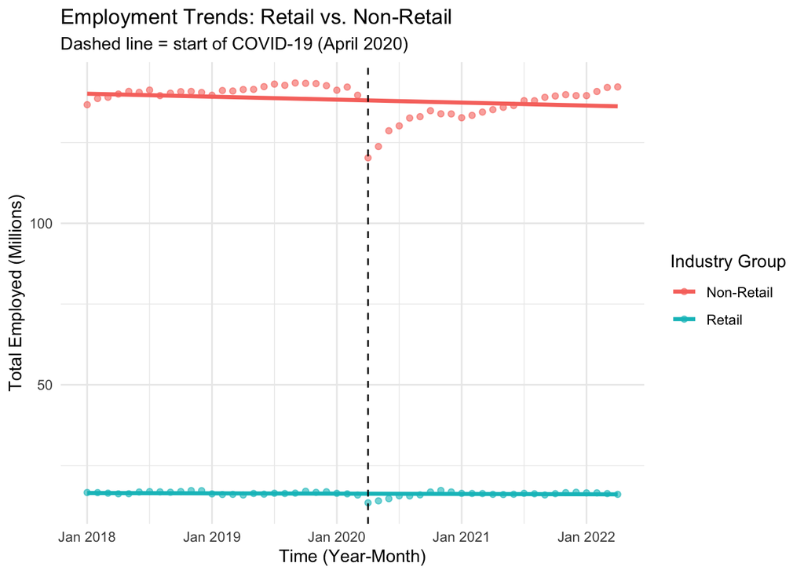

```r
ggplot(combined_emp_ts, aes(x = year_month, y = total_employed_mil, color = industry_group)) +
  geom_point(alpha = 0.6) +
  geom_smooth(method = "lm", se = FALSE, linewidth = 1.2) +
  geom_vline(xintercept = as.yearmon("2020-04"), linetype = "dashed", color = "black") +
  labs(
    title = "Employment Trends: Retail vs. Non-Retail",
    subtitle = "Dashed line = start of COVID-19 (April 2020)",
    x = "Time (Year-Month)", y = "Total Employed (Millions)", color = "Industry Group"
  ) +
  theme_minimal()
```

At the onset of the pandemic in April 2020, both retail and non-retail sectors experienced employment declines. This visual and statistical comparison aims to capture the differential impact of COVID-19 on employment across these groups. While retail is known to be particularly vulnerable to lockdowns and social distancing measures, interestingly, non-retail employment showed a larger immediate drop than retail employment. This may reflect the broad and heterogeneous nature of the non-retail category, which includes a wide range of services, some of which were severely disrupted during the early stages of the pandemic.

2. Retail vs Non-Retail Diff-in-Diff Regression

```r
model_diff <- feols(
  total_employed_mil ~ post_covid + retail + interaction + month_index,
  data = combined_emp_ts
)
etable(model_diff, tex = FALSE)
```

```
                        model_diff
Dependent Var.: total_employed_mil

Constant         138.3*** (0.6195)
post_covid       -11.07*** (1.023)
retail          -124.4*** (0.6357)
interaction      5.446*** (0.9165)
month_index     0.0990*** (0.0152)
_______________ __________________
S.E. type                      IID
Observations                   104
R2                         0.99861
Adj. R2                    0.99855
---
Signif. codes: 0 '***' 0.001 '**' 0.01 '*' 0.05 '.' 0.1 ' ' 1
```

In this difference-in-differences (DiD) mode, the dependent variable is total employment in millions (`total_employed_mil`), modeled as a function of:

- `post_covid`: an indicator for the period after April 2020 (pandemic onset),
- `retail`: an indicator for the retail industry group,
- `interaction`: the interaction between `post_covid` and `retail` capturing the differential effect of COVID-19 on retail employment relative to non-retail,
- `month_index`: a linear time trend to control for underlying temporal trends in employment.

**Results**:

- Non-retail employment dropped significantly by about **11.07 million** (`post_covid` coefficient), holding other factors constant.
- The positive and statistically significant interaction term (`5.446 million`) indicates that retail employment experienced a smaller employment decline relative to non-retail industries during the pandemic period.
3. However, the baseline employment level for non-retail industries before COVID-19 is approximately **138.3 million,** while retail industries had a much lower baseline employment level, approximately **124.4 million fewer** than non-retail sectors before COVID-19. This means that all though retail employment did not drop as much as non-retail, it does not mean retail was more resilient to COVID-19, as there was simply more non-retail data.
3. Average Employment Rate Analysis

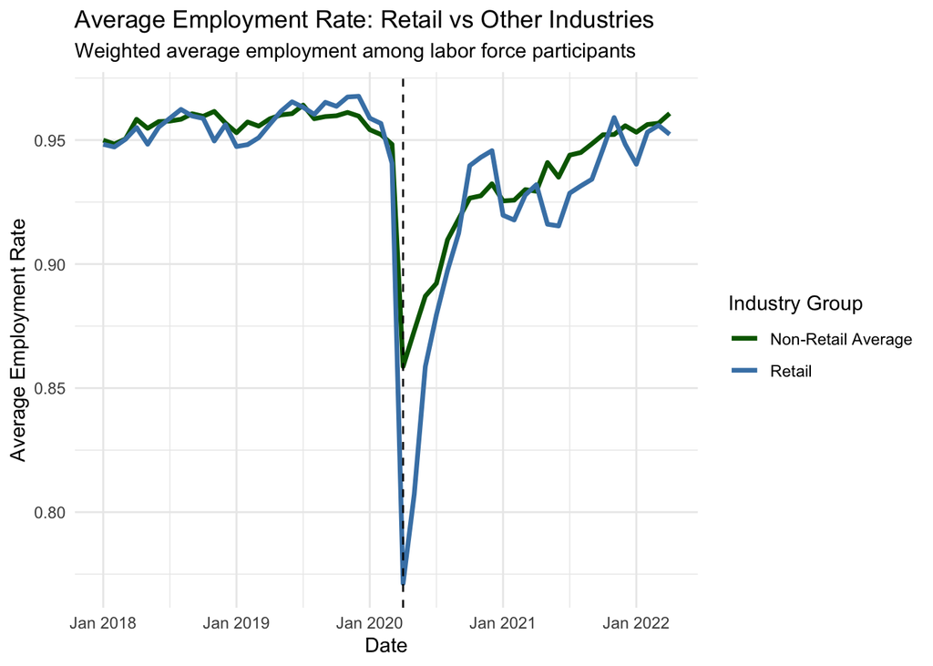

```r
#Plot: Average Employment Rate: Retail vs Other Industries
ggplot(avg_by_retail, aes(x = year_month, y = mean_employed, color = retail_label)) +
  geom_line(linewidth = 1.2) +
  geom_vline(xintercept = as.yearmon("2020-04"), linetype = "dashed", color = "black") +
  labs(
    title = "Average Employment Rate: Retail vs Other Industries",
    subtitle = "Weighted average employment among labor force participants",
    x = "Date", y = "Average Employment Rate", color = "Industry Group"
  ) +
  scale_color_manual(values = c("darkgreen", "steelblue")) +
  theme_minimal()
```

This plot visualizes the weighted average employment rates for retail and non-retail industries over time, focusing on labor force participants. The vertical dashed line marks April 2020, signaling the start of the COVID-19 pandemic. By using the average employment rate, we can now fairly analyze the effect of COVID-19 on retail and non-retail employment, without worrying about sample sizes.

Both retail and non-retail sectors exhibit stable employment rates prior to the pandemic. Following April 2020, a clear drop in employment rates is observed across both groups, consistent with widespread economic disruptions.

Notably, the retail sector (blue line) shows a steeper decline in average employment rate compared to non-retail industries (green line). This suggests that it was actually retail workers that faced relatively greater employment challenges during the pandemic, potentially due to lockdown measures and reduced consumer foot traffic.

Over time, both sectors exhibit signs of recovery, with employment rates trending upward post-pandemic onset. This plot complements earlier findings on total employment, adding nuance by illustrating changes in employment rates rather than absolute employment counts.

4. Industry Group Heterogeneity

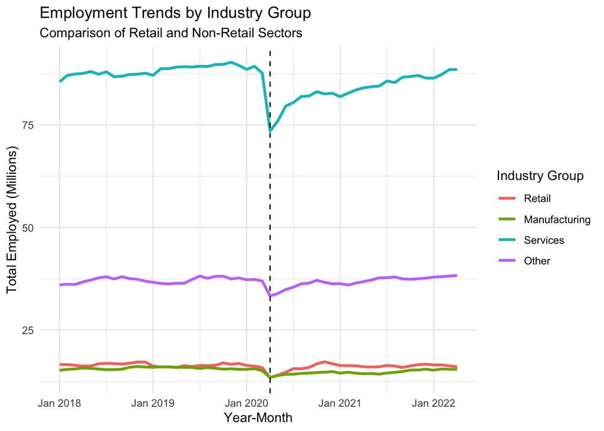

```r
ggplot(industry_group_ts, aes(x = year_month, y = total_employed_mil, color = industry_group)) +
  geom_line(linewidth = 1.1) +
  geom_vline(xintercept = as.yearmon("2020-04"), linetype = "dashed", color = "black") +
  labs(
    title = "Employment Trends by Industry Group",
    subtitle = "Comparison of Retail and Non-Retail Sectors",
    x = "Year-Month", y = "Total Employed (Millions)", color = "Industry Group"
  ) +
  theme_minimal()
```

5. Industry Group Heterogeneity regression interaction analysis

```r
model_het <- feols(
  total_employed_mil ~ post_covid * industry_group + month_index,
  data = industry_group_ts
)
```

```
The variables 'industry_groupHospitality' and 'post_covid:industry_groupHospitality' have been removed because of collinearity (see $collin.var).
```

```r
etable(model_het, tex = FALSE)
```

```
                                                  model_het
Dependent Var.:                          total_employed_mil

Constant                                  15.13*** (0.2904)
post_covid                               -3.046*** (0.4621)
industry_groupManufacturing               -0.7782* (0.3429)
industry_groupServices                    71.69*** (0.3429)
industry_groupOther                       20.69*** (0.3429)
month_index                              0.0248*** (0.0029)
post_covid x industry_groupManufacturing   -0.4895 (0.4945)
post_covid x industry_groupServices      -4.085*** (0.4945)
post_covid x industry_groupOther            0.0692 (0.4945)
________________________________________ __________________
S.E. type                                               IID
Observations                                            208
R2                                                  0.99817
Adj. R2                                             0.99809
---
Signif. codes: 0 '***' 0.001 '**' 0.01 '*' 0.05 '.' 0.1 ' ' 1
```

Interpretation:

| Variable | Coefficient (Std. Error) | Interpretation |
| --- | --- | --- |
| **post_covid** | -3.05*** (0.46) | Retail employment fell by ~3 million post-COVID, relative to its pre-COVID trend. |
| **post_covid × Manufacturing** | -0.49 (0.49) | Not statistically significant – the decline in manufacturing was similar to that of retail. |
| **post_covid × Services** | -4.09*** (0.49) | Services experienced a significantly *larger* drop (approx. 4.1 million more than retail). |
| **post_covid × Other** | 0.07 (0.49) | No significant difference from retail. |
| **month_index** | 0.025*** (0.0029) | A small, positive time trend in employment, capturing recovery or seasonal shifts. |

Retail was clearly hit by the pandemic, but **the services sector was hit even harder**, with an estimated 4.1 million more job losses than retail post-COVID, all else equal. The effect for **manufacturing** was slightly worse than retail but not statistically distinguishable, while the “Other” category appears unaffected in relative terms.

This result reflects the **industry-specific exposure** to lockdowns and consumer behavior shifts. Many service, sector jobs, especially in face-to-face settings like hospitality, education, and healthcare, were suspended or terminated due to COVID-related restrictions. The **retail sector**, while vulnerable, may have benefited partially from increased demand in essential goods or a pivot to online platforms.

**Assumptions:**

1. **Parallel Trends Assumption (for DiD):** Our DiD model compares changes in employment between retail and non-retail sectors before and after April 2020. A critical identifying assumption is that, in the absence of COVID-19, employment trends in both groups would have followed parallel paths over time. The employment trend plot (see *Employment Trends: Retail vs. Non-Retail*) shows that both groups had relatively stable and similar trajectories before April 2020. While not a formal test, the visual evidence supports the plausibility of the parallel trends assumption.
2. **Independence and Identically Distributed Errors (IID):** Our regression models assume that the error terms are independently and identically distributed, without serial correlation or heteroskedasticity. Given the time-series structure of the data, some autocorrelation is likely. A more conservative analysis might cluster standard errors by industry or month. However, for this exploratory analysis, we proceed with IID errors and interpret results cautiously.

**Summary**: Using a combination of visualizations and regression models, we tracked changes in total employment and average employment rates before and after April 2020. While retail did not experience the largest absolute decline in jobs, its workers faced sharper drops in employment rates, potentially reflecting a high share of part-time and frontline roles vulnerable to temporary layoffs. The services sector, however, bore the brunt of job losses, underscoring the pandemic’s uneven impact across industries.

### 3. What has changed about who is working and earning income during the pandemic?

This analysis looks into how COVID-19 affected the weekly earning among employed individuals. Specifically looking at the retail sector and whether they had different earning trend compared to other industries. Retail workers tend to be lower paid and are more vulnerable to economic shocks. So looking at this sector would provide us with important insight on who is earning income in the post-COVID market.

**THE DATA AND CLEANING PROCESS:**

We use the current population survey micro data from IPUMS, cover the two years prior to COVID and two years post COVID. To clean the data we first converted the labelled variables to factor using haven: :as_factor, then filtered for observations with valid year, month, and work per hour data. Next, we defined employed individuals as those either “at work”, or “Has job, not at work last week.”. Afterwards, we had to be able to identify who the retail workers are. We did this by uploading the list of industry codes from canvas names “indnames.csv”. Afterwards, we had to define the post-COVID period as April 2020 to April 2022.

**ANALYTICAL METHOD: DIFFERENCE-IN-DIFFERENCE**

```r
model_did_weighted_q3 <- feols(
  earnings_q3 ~ is_retail_q3* post_covid_q3 + factor(year) + factor(month),
  data = cleaned_data_q3, weights = ~weight_q3
)
```

```
The variables 'is_retail_q3TRUE' and 'is_retail_q3TRUE:post_covid_q3' have been removed because of collinearity (see $collin.var).
```

```r
summary(model_did_weighted_q3)
```

```
OLS estimation, Dep. Var.: earnings_q3
Observations: 2,559,125
Weights: weight_q3
Standard-errors: IID
                         Estimate Std. Error     t value   Pr(>|t|)
(Intercept)            590.375838   0.410339 1438.751432  < 2.2e-16 ***
post_covid_q3            1.135874   0.577206    1.967884 4.9082e-02 *
factor(year)2019         0.374997   0.306567    1.223216 2.2125e-01
factor(year)2020        -1.276201   0.528326   -2.415556 1.5711e-02 *
factor(year)2021        -2.425421   0.654466   -3.705953 2.1060e-04 ***
factor(year)2022        -2.318229   0.796420   -2.910812 3.6049e-03 **
factor(month)February   -0.573941   0.478624   -1.199148 2.3047e-01
factor(month)March      -0.367672   0.478257   -0.768775 4.4203e-01
factor(month)April       1.395925   0.494918    2.820516 4.7947e-03 **
factor(month)May         2.919705   0.536349    5.443667 5.2199e-08 ***
factor(month)June        4.594116   0.534926    8.588323  < 2.2e-16 ***
factor(month)July        5.630557   0.533993   10.544261  < 2.2e-16 ***
factor(month)August      6.129929   0.534260   11.473678  < 2.2e-16 ***
factor(month)September   3.644815   0.533289    6.834599 8.2253e-12 ***
factor(month)October     2.354900   0.532413    4.423071 9.7312e-06 ***
factor(month)November    1.615057   0.532256    3.034362 2.4105e-03 **
factor(month)December    1.077402   0.532534    2.023160 4.3057e-02 *
... 2 variables were removed because of collinearity (is_retail_q3TRUE and is_retail_q3TRUE:post_covid_q3)
---
Signif. codes:  0 '***' 0.001 '**' 0.01 '*' 0.05 '.' 0.1 ' ' 1
RMSE: 9,102.8   Adj. R2: 2.01e-4
```

```r
# or etable(model_did_weighted_q3)?
```

**VISUAL PRESENTAION**

[figure not shown]

```r
ggplot(employment_summary_filtered_q3, aes(x = interaction(year, month), y = avg_earnings_q3, color = is_retail_q3)) +
 geom_line(aes(group = is_retail_q3)) +
 labs(x = "Time", y = "Average Weekly Earnings (USD)", color = "Retail Sector") +
 theme_minimal() +
 theme(axis.text.x = element_text(angle = 90)) +
ggtitle("Trends in Weekly Earnings Before and After COVID")
```

Our study also points to the importance of ongoing data collection and analysis to better understand how employment and income patterns evolve as the economy adjusts post-pandemic. Such insights are vital for crafting policies that not only promote recovery but also address longstanding inequities revealed and exacerbated by the crisis.